# Overview

Dataset info

| Number of variables | 27 |
| --- | --- |
| Number of observations | 1452670 |
| Total Missing (%) | 38.1% |
| Total size in memory | 299.2 MiB |
| Average record size in memory | 216.0 B |

Variables types

| Numeric | 7 |
| --- | --- |
| Categorical | 11 |
| Boolean | 0 |
| Date | 0 |
| Text (Unique) | 2 |
| Rejected | 6 |
| Unsupported | 1 |

Warnings

- `V_ABOK` has 313809 / 21.6% missing values Missing
- `V_ABOK` has 16461 / 1.1% zeros Zeros
- `V_ABOK_TIME` has 633059 / 43.6% missing values Missing
- `V_BRANCH_CD` has 653954 / 45.0% missing values Missing
- `V_CASE_NO` has 819611 / 56.4% missing values Missing
- `V_CASE_NO` is an unsupported type, check if it needs cleaning or further analysis Warning
- `V_COLOR` has 633059 / 43.6% missing values Missing
- `V_COLOR` has a high cardinality: 138 distinct values Warning
- `V_DIST_CD` has 20895 / 1.4% missing values Missing
- `V_DIST_CD` has a high cardinality: 1592 distinct values Warning
- `V_ENGINE_NO` has a high cardinality: 1401261 distinct values Warning
- `V_FCOK_TIME` has 633059 / 43.6% missing values Missing
- `V_INVOICE_NO` has 819611 / 56.4% missing values Missing
- `V_INVOICE_NO` has a high cardinality: 11929 distinct values Warning
- `V_KEY_NO` has a high cardinality: 8918 distinct values Warning
- `V_MISSON_NO` has 819611 / 56.4% missing values Missing
- `V_MISSON_NO` has a high cardinality: 160335 distinct values Warning
- `V_MOTOR_NO` has 1452670 / 100.0% missing values Missing
- `V_MOTOR_NO` has constant value Rejected
- `V_PLANT_CD` has 1452670 / 100.0% missing values Missing
- `V_PLANT_CD` has constant value Rejected
- `V_PROD_MODEL_CD` has 819611 / 56.4% missing values Missing
- `V_PROD_MODEL_CD` has a high cardinality: 834 distinct values Warning
- `V_SALES_MODEL_CD` has a high cardinality: 1607 distinct values Warning
- `V_SALES_MODEL_NM` has 1452670 / 100.0% missing values Missing
- `V_SALES_MODEL_NM` has constant value Rejected
- `V_SALES_NO` has 819611 / 56.4% missing values Missing
- `V_SALES_NO` has a high cardinality: 5537 distinct values Warning
- `V_SHIPPING_ABOK` has 1452670 / 100.0% missing values Missing
- `V_SHIPPING_ABOK` has constant value Rejected
- `V_SHIPPING_DATE` has 43660 / 3.0% missing values Missing
- `V_SHIPPING_FCOK` has 1452670 / 100.0% missing values Missing
- `V_SHIPPING_FCOK` has constant value Rejected
- `V_SPEC` has 633059 / 43.6% missing values Missing
- `V_SRC_DIV` has constant value 1 Rejected

# Variables

V_ABOK  
Numeric

| Distinct count | 301 |
| --- | --- |
| Unique (%) | 0.0% |
| Missing (%) | 21.6% |
| Missing (n) | 313809 |
| Infinite (%) | 0.0% |
| Infinite (n) | 0 |

| Mean | 19891000 |
| --- | --- |
| Minimum | 0 |
| Maximum | 20190000 |
| Zeros (%) | 1.1% |

Toggle details

**Statistics**

Quantile statistics

| Minimum | 0 |
| --- | --- |
| 5-th percentile | 20180000 |
| Q1 | 20181000 |
| Median | 20181000 |
| Q3 | 20181000 |
| 95-th percentile | 20190000 |
| Maximum | 20190000 |
| Range | 20190000 |
| Interquartile range | 526 |

Descriptive statistics

| Standard deviation | 2408900 |
| --- | --- |
| Coef of variation | 0.1211 |
| Kurtosis | 64.199 |
| Mean | 19891000 |
| MAD | 575010 |
| Skewness | -8.1363 |
| Sum | 22653000000000 |
| Variance | 5802800000000 |
| Memory size | 11.1 MiB |

**Histogram**

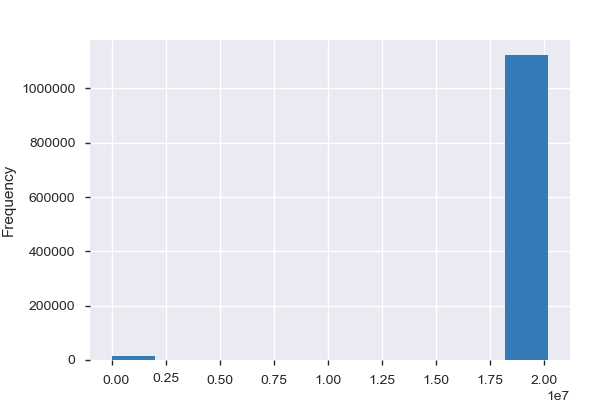

**Common Values**

| Value | Count | Frequency (%) |  |
| --- | --- | --- | --- |
| 0.0 | 16461 | 1.1% |  |
| 20180718.0 | 4980 | 0.3% |  |
| 20180716.0 | 4882 | 0.3% |  |
| 20180717.0 | 4882 | 0.3% |  |
| 20180704.0 | 4809 | 0.3% |  |
| 20180703.0 | 4792 | 0.3% |  |
| 20180705.0 | 4765 | 0.3% |  |
| 20180723.0 | 4762 | 0.3% |  |
| 20180719.0 | 4686 | 0.3% |  |
| 20181220.0 | 4665 | 0.3% |  |
| Other values (290) | 1079177 | 74.3% |  |
| (Missing) | 313809 | 21.6% |  |

**Extreme Values**

Minimum 5 values

| Value | Count | Frequency (%) |  |
| --- | --- | --- | --- |
| 0.0 | 16461 | 1.1% |  |
| 20000000.0 | 1020 | 0.1% |  |
| 20180213.0 | 5 | 0.0% |  |
| 20180214.0 | 6 | 0.0% |  |
| 20180302.0 | 1 | 0.0% |  |

Maximum 5 values

| Value | Count | Frequency (%) |  |
| --- | --- | --- | --- |
| 20190326.0 | 4293 | 0.3% |  |
| 20190327.0 | 4464 | 0.3% |  |
| 20190328.0 | 4517 | 0.3% |  |
| 20190329.0 | 3892 | 0.3% |  |
| 20190330.0 | 2501 | 0.2% |  |

V_ABOK_TIME  
Numeric

| Distinct count | 74408 |
| --- | --- |
| Unique (%) | 5.1% |
| Missing (%) | 43.6% |
| Missing (n) | 633059 |
| Infinite (%) | 0.0% |
| Infinite (n) | 0 |

| Mean | 161330 |
| --- | --- |
| Minimum | 0 |
| Maximum | 274840 |
| Zeros (%) | 0.1% |

Toggle details

**Statistics**

Quantile statistics

| Minimum | 0 |
| --- | --- |
| 5-th percentile | 71921 |
| Q1 | 105350 |
| Median | 161700 |
| Q3 | 213930 |
| 95-th percentile | 253630 |
| Maximum | 274840 |
| Range | 274840 |
| Interquartile range | 108580 |

Descriptive statistics

| Standard deviation | 59505 |
| --- | --- |
| Coef of variation | 0.36885 |
| Kurtosis | -1.1046 |
| Mean | 161330 |
| MAD | 51060 |
| Skewness | 0.0031727 |
| Sum | 132230000000 |
| Variance | 3540800000 |
| Memory size | 11.1 MiB |

**Histogram**

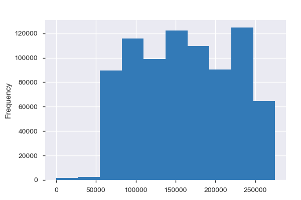

**Common Values**

| Value | Count | Frequency (%) |  |
| --- | --- | --- | --- |
| 0.0 | 1020 | 0.1% |  |
| 40258.0 | 50 | 0.0% |  |
| 33429.0 | 40 | 0.0% |  |
| 20059.0 | 40 | 0.0% |  |
| 30251.0 | 40 | 0.0% |  |
| 30304.0 | 39 | 0.0% |  |
| 63350.0 | 35 | 0.0% |  |
| 63349.0 | 35 | 0.0% |  |
| 41014.0 | 35 | 0.0% |  |
| 40453.0 | 34 | 0.0% |  |
| Other values (74397) | 818243 | 56.3% |  |
| (Missing) | 633059 | 43.6% |  |

**Extreme Values**

Minimum 5 values

| Value | Count | Frequency (%) |  |
| --- | --- | --- | --- |
| 0.0 | 1020 | 0.1% |  |
| 2332.0 | 30 | 0.0% |  |
| 2433.0 | 16 | 0.0% |  |
| 2434.0 | 1 | 0.0% |  |
| 2458.0 | 10 | 0.0% |  |

Maximum 5 values

| Value | Count | Frequency (%) |  |
| --- | --- | --- | --- |
| 274819.0 | 1 | 0.0% |  |
| 274821.0 | 1 | 0.0% |  |
| 274831.0 | 2 | 0.0% |  |
| 274833.0 | 1 | 0.0% |  |
| 274835.0 | 1 | 0.0% |  |

V_BASE_CD  
Numeric

| Distinct count | 10 |
| --- | --- |
| Unique (%) | 0.0% |
| Missing (%) | 0.0% |
| Missing (n) | 0 |
| Infinite (%) | 0.0% |
| Infinite (n) | 0 |

| Mean | 115100 |
| --- | --- |
| Minimum | 100100 |
| Maximum | 999999 |
| Zeros (%) | 0.0% |

Toggle details

**Statistics**

Quantile statistics

| Minimum | 100100 |
| --- | --- |
| 5-th percentile | 100100 |
| Q1 | 100100 |
| Median | 100100 |
| Q3 | 111010 |
| 95-th percentile | 227510 |
| Maximum | 999999 |
| Range | 899899 |
| Interquartile range | 10910 |

Descriptive statistics

| Standard deviation | 42126 |
| --- | --- |
| Coef of variation | 0.366 |
| Kurtosis | 96.28 |
| Mean | 115100 |
| MAD | 23259 |
| Skewness | 6.2979 |
| Sum | 167198913366 |
| Variance | 1774600000 |
| Memory size | 11.1 MiB |

**Histogram**

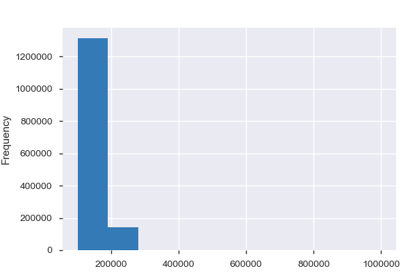

**Common Values**

| Value | Count | Frequency (%) |  |
| --- | --- | --- | --- |
| 100100 | 1081439 | 74.4% |  |
| 227510 | 140616 | 9.7% |  |
| 111010 | 125201 | 8.6% |  |
| 123500 | 34082 | 2.3% |  |
| 111700 | 28924 | 2.0% |  |
| 118700 | 22784 | 1.6% |  |
| 123050 | 11977 | 0.8% |  |
| 106010 | 4701 | 0.3% |  |
| 105370 | 2242 | 0.2% |  |
| 999999 | 704 | 0.0% |  |

**Extreme Values**

Minimum 5 values

| Value | Count | Frequency (%) |  |
| --- | --- | --- | --- |
| 100100 | 1081439 | 74.4% |  |
| 105370 | 2242 | 0.2% |  |
| 106010 | 4701 | 0.3% |  |
| 111010 | 125201 | 8.6% |  |
| 111700 | 28924 | 2.0% |  |

Maximum 5 values

| Value | Count | Frequency (%) |  |
| --- | --- | --- | --- |
| 118700 | 22784 | 1.6% |  |
| 123050 | 11977 | 0.8% |  |
| 123500 | 34082 | 2.3% |  |
| 227510 | 140616 | 9.7% |  |
| 999999 | 704 | 0.0% |  |

V_BRANCH_CD  
Numeric

| Distinct count | 456 |
| --- | --- |
| Unique (%) | 0.0% |
| Missing (%) | 45.0% |
| Missing (n) | 653954 |
| Infinite (%) | 0.0% |
| Infinite (n) | 0 |

| Mean | 438950 |
| --- | --- |
| Minimum | 61310 |
| Maximum | 721340 |
| Zeros (%) | 0.0% |

Toggle details

**Statistics**

Quantile statistics

| Minimum | 61310 |
| --- | --- |
| 5-th percentile | 202210 |
| Q1 | 315410 |
| Median | 407750 |
| Q3 | 519060 |
| 95-th percentile | 707180 |
| Maximum | 721340 |
| Range | 660030 |
| Interquartile range | 203650 |

Descriptive statistics

| Standard deviation | 159630 |
| --- | --- |
| Coef of variation | 0.36366 |
| Kurtosis | -0.84095 |
| Mean | 438950 |
| MAD | 134320 |
| Skewness | 0.24185 |
| Sum | 350590000000 |
| Variance | 25481000000 |
| Memory size | 11.1 MiB |

**Histogram**

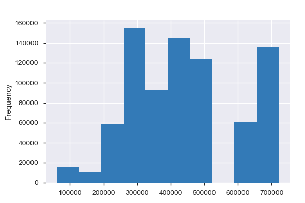

**Common Values**

| Value | Count | Frequency (%) |  |
| --- | --- | --- | --- |
| 361000.0 | 44751 | 3.1% |  |
| 672310.0 | 39519 | 2.7% |  |
| 506070.0 | 24213 | 1.7% |  |
| 387000.0 | 19520 | 1.3% |  |
| 503560.0 | 18866 | 1.3% |  |
| 412270.0 | 18175 | 1.3% |  |
| 301970.0 | 17272 | 1.2% |  |
| 411130.0 | 16869 | 1.2% |  |
| 603210.0 | 16715 | 1.2% |  |
| 711530.0 | 16136 | 1.1% |  |
| Other values (445) | 566680 | 39.0% |  |
| (Missing) | 653954 | 45.0% |  |

**Extreme Values**

Minimum 5 values

| Value | Count | Frequency (%) |  |
| --- | --- | --- | --- |
| 61310.0 | 291 | 0.0% |  |
| 110110.0 | 132 | 0.0% |  |
| 110260.0 | 4 | 0.0% |  |
| 110270.0 | 498 | 0.0% |  |
| 120120.0 | 3442 | 0.2% |  |

Maximum 5 values

| Value | Count | Frequency (%) |  |
| --- | --- | --- | --- |
| 714270.0 | 38 | 0.0% |  |
| 721010.0 | 2 | 0.0% |  |
| 721120.0 | 57 | 0.0% |  |
| 721140.0 | 2470 | 0.2% |  |
| 721340.0 | 88 | 0.0% |  |

V_CASE_NO  
Unsupported

*This variable is an unsupported type, check if it needs cleaning or further analysis*

| Unsupported value |
| --- |

V_COLOR  
Categorical

| Distinct count | 138 |
| --- | --- |
| Unique (%) | 0.0% |
| Missing (%) | 43.6% |
| Missing (n) | 633059 |

| 26U | 145351 |
| --- | --- |
| ZVR | 117792 |
| Z2S | 94691 |
| Other values (134) | 461777 |
| (Missing) | 633059 |

Toggle details

| Value | Count | Frequency (%) |  |
| --- | --- | --- | --- |
| 26U | 145351 | 10.0% |  |
| ZVR | 117792 | 8.1% |  |
| Z2S | 94691 | 6.5% |  |
| ZJ3 | 74550 | 5.1% |  |
| ZSF | 30866 | 2.1% |  |
| ZVG | 18040 | 1.2% |  |
| ZVC | 17570 | 1.2% |  |
| ZYW | 15705 | 1.1% |  |
| ZJH | 14006 | 1.0% |  |
| ZMV | 13384 | 0.9% |  |
| Other values (127) | 277656 | 19.1% |  |
| (Missing) | 633059 | 43.6% |  |

V_CRT_TIME_STAMP  
Categorical, Unique

| First 3 values |
| --- |
| 19-04-01 15:10:13.018242000 |
| 19-04-01 15:46:08.963727000 |
| 19-04-19 15:29:41.173680000 |

| Last 3 values |
| --- |
| 19-04-01 14:43:41.592283000 |
| 19-04-01 15:33:46.982583000 |
| 19-04-01 15:49:07.854413000 |

Toggle details

| Value | Count | Frequency (%) |  |
| --- | --- | --- | --- |
| 19-04-01 14:20:30.317302000 | 1 | 0.0% |  |
| 19-04-01 14:20:30.326828000 | 1 | 0.0% |  |
| 19-04-01 14:20:30.333645000 | 1 | 0.0% |  |
| 19-04-01 14:20:30.341440000 | 1 | 0.0% |  |
| 19-04-01 14:20:30.348045000 | 1 | 0.0% |  |

| Value | Count | Frequency (%) |  |
| --- | --- | --- | --- |
| 19-04-19 15:34:40.135666000 | 1 | 0.0% |  |
| 19-04-19 15:34:40.139362000 | 1 | 0.0% |  |
| 19-04-19 15:34:40.143143000 | 1 | 0.0% |  |
| 19-04-19 15:34:40.146459000 | 1 | 0.0% |  |
| 19-04-19 15:34:40.149645000 | 1 | 0.0% |  |

V_DIST_CD  
Categorical

| Distinct count | 1592 |
| --- | --- |
| Unique (%) | 0.1% |
| Missing (%) | 1.4% |
| Missing (n) | 20895 |

| 361000.0 | 43436 |
| --- | --- |
| 670000.0 | 38528 |
| 502240.0 | 25345 |
| Other values (1588) | 1324466 |

Toggle details

| Value | Count | Frequency (%) |  |
| --- | --- | --- | --- |
| 361000.0 | 43436 | 3.0% |  |
| 670000.0 | 38528 | 2.7% |  |
| 502240.0 | 25345 | 1.7% |  |
| 220010.0 | 21131 | 1.5% |  |
| 210010.0 | 20584 | 1.4% |  |
| 387000.0 | 18955 | 1.3% |  |
| 304083.0 | 18917 | 1.3% |  |
| 503110.0 | 18874 | 1.3% |  |
| 213010.0 | 18762 | 1.3% |  |
| 402230.0 | 18254 | 1.3% |  |
| Other values (1581) | 1188989 | 81.8% |  |
| (Missing) | 20895 | 1.4% |  |

V_ENGINE_NO  
Categorical

| Distinct count | 1401261 |
| --- | --- |
| Unique (%) | 96.5% |
| Missing (%) | 0.0% |
| Missing (n) | 0 |

| 190227 | 292 |
| --- | --- |
| 190221 | 269 |
| 180907 | 267 |
| Other values (1401258) | 1451842 |

Toggle details

| Value | Count | Frequency (%) |  |
| --- | --- | --- | --- |
| 190227 | 292 | 0.0% |  |
| 190221 | 269 | 0.0% |  |
| 180907 | 267 | 0.0% |  |
| 181012 | 264 | 0.0% |  |
| 190226 | 263 | 0.0% |  |
| 190307 | 261 | 0.0% |  |
| 190128 | 260 | 0.0% |  |
| 180914 | 260 | 0.0% |  |
| 190125 | 260 | 0.0% |  |
| 190123 | 258 | 0.0% |  |
| Other values (1401251) | 1450016 | 99.8% |  |

V_FCOK  
Numeric

| Distinct count | 342 |
| --- | --- |
| Unique (%) | 0.0% |
| Missing (%) | 0.0% |
| Missing (n) | 0 |
| Infinite (%) | 0.0% |
| Infinite (n) | 0 |

| Mean | 20183000 |
| --- | --- |
| Minimum | 20180402 |
| Maximum | 20190330 |
| Zeros (%) | 0.0% |

Toggle details

**Statistics**

Quantile statistics

| Minimum | 20180402 |
| --- | --- |
| 5-th percentile | 20180000 |
| Q1 | 20181000 |
| Median | 20181000 |
| Q3 | 20190000 |
| 95-th percentile | 20190000 |
| Maximum | 20190330 |
| Range | 9928 |
| Interquartile range | 9405 |

Descriptive statistics

| Standard deviation | 4130.4 |
| --- | --- |
| Coef of variation | 0.00020465 |
| Kurtosis | -0.81958 |
| Mean | 20183000 |
| MAD | 3622.1 |
| Skewness | 1.0792 |
| Sum | 29319635172337 |
| Variance | 17060000 |
| Memory size | 11.1 MiB |

**Histogram**

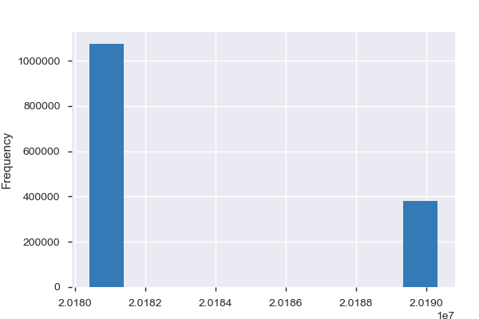

**Common Values**

| Value | Count | Frequency (%) |  |
| --- | --- | --- | --- |
| 20190129 | 6609 | 0.5% |  |
| 20190123 | 6410 | 0.4% |  |
| 20190128 | 6387 | 0.4% |  |
| 20190130 | 6376 | 0.4% |  |
| 20190110 | 6346 | 0.4% |  |
| 20190131 | 6344 | 0.4% |  |
| 20190116 | 6342 | 0.4% |  |
| 20181217 | 6290 | 0.4% |  |
| 20190114 | 6248 | 0.4% |  |
| 20180410 | 6228 | 0.4% |  |
| Other values (332) | 1389090 | 95.6% |  |

**Extreme Values**

Minimum 5 values

| Value | Count | Frequency (%) |  |
| --- | --- | --- | --- |
| 20180402 | 4801 | 0.3% |  |
| 20180403 | 5839 | 0.4% |  |
| 20180404 | 5393 | 0.4% |  |
| 20180405 | 6017 | 0.4% |  |
| 20180406 | 5339 | 0.4% |  |

Maximum 5 values

| Value | Count | Frequency (%) |  |
| --- | --- | --- | --- |
| 20190326 | 5212 | 0.4% |  |
| 20190327 | 5204 | 0.4% |  |
| 20190328 | 5190 | 0.4% |  |
| 20190329 | 4649 | 0.3% |  |
| 20190330 | 3046 | 0.2% |  |

V_FCOK_TIME  
Numeric

| Distinct count | 75002 |
| --- | --- |
| Unique (%) | 5.2% |
| Missing (%) | 43.6% |
| Missing (n) | 633059 |
| Infinite (%) | 0.0% |
| Infinite (n) | 0 |

| Mean | 163820 |
| --- | --- |
| Minimum | 0 |
| Maximum | 274840 |
| Zeros (%) | 0.1% |

Toggle details

**Statistics**

Quantile statistics

| Minimum | 0 |
| --- | --- |
| 5-th percentile | 72911 |
| Q1 | 112930 |
| Median | 162830 |
| Q3 | 214960 |
| 95-th percentile | 255160 |
| Maximum | 274840 |
| Range | 274840 |
| Interquartile range | 102020 |

Descriptive statistics

| Standard deviation | 58830 |
| --- | --- |
| Coef of variation | 0.35912 |
| Kurtosis | -1.0976 |
| Mean | 163820 |
| MAD | 50277 |
| Skewness | 0.0094082 |
| Sum | 134270000000 |
| Variance | 3461000000 |
| Memory size | 11.1 MiB |

**Histogram**

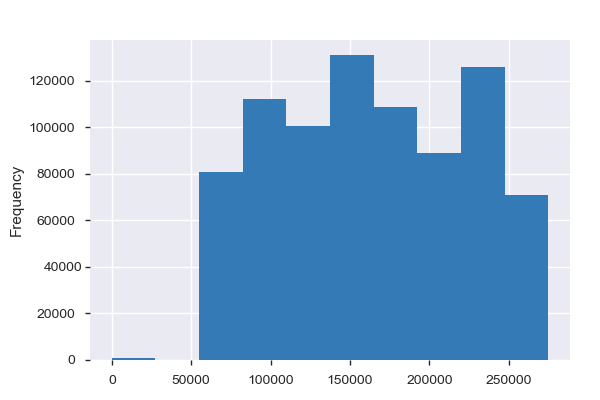

**Common Values**

| Value | Count | Frequency (%) |  |
| --- | --- | --- | --- |
| 0.0 | 1020 | 0.1% |  |
| 130756.0 | 30 | 0.0% |  |
| 123956.0 | 29 | 0.0% |  |
| 202919.0 | 29 | 0.0% |  |
| 230322.0 | 29 | 0.0% |  |
| 182717.0 | 29 | 0.0% |  |
| 80611.0 | 29 | 0.0% |  |
| 130018.0 | 28 | 0.0% |  |
| 64142.0 | 28 | 0.0% |  |
| 100546.0 | 28 | 0.0% |  |
| Other values (74991) | 818332 | 56.3% |  |
| (Missing) | 633059 | 43.6% |  |

**Extreme Values**

Minimum 5 values

| Value | Count | Frequency (%) |  |
| --- | --- | --- | --- |
| 0.0 | 1020 | 0.1% |  |
| 60125.0 | 1 | 0.0% |  |
| 60127.0 | 1 | 0.0% |  |
| 60132.0 | 1 | 0.0% |  |
| 60210.0 | 1 | 0.0% |  |

Maximum 5 values

| Value | Count | Frequency (%) |  |
| --- | --- | --- | --- |
| 274813.0 | 1 | 0.0% |  |
| 274814.0 | 1 | 0.0% |  |
| 274816.0 | 1 | 0.0% |  |
| 274819.0 | 1 | 0.0% |  |
| 274836.0 | 1 | 0.0% |  |

V_INVOICE_NO  
Categorical

| Distinct count | 11929 |
| --- | --- |
| Unique (%) | 0.8% |
| Missing (%) | 56.4% |
| Missing (n) | 819611 |

|  | 10459 |
| --- | --- |
| D1-26435 | 1645 |
| BC-11114 | 1507 |
| Other values (11925) | 619448 |
| (Missing) | 819611 |

Toggle details

| Value | Count | Frequency (%) |  |
| --- | --- | --- | --- |
|  | 10459 | 0.7% |  |
| D1-26435 | 1645 | 0.1% |  |
| BC-11114 | 1507 | 0.1% |  |
| BT-13569 | 1453 | 0.1% |  |
| BT-13548 | 1293 | 0.1% |  |
| BT-13607 | 1290 | 0.1% |  |
| BT-13539 | 1012 | 0.1% |  |
| BT-13676 | 993 | 0.1% |  |
| BC-11158 | 980 | 0.1% |  |
| AS-20211 | 978 | 0.1% |  |
| Other values (11918) | 611449 | 42.1% |  |
| (Missing) | 819611 | 56.4% |  |

V_KEY_NO  
Categorical

| Distinct count | 8918 |
| --- | --- |
| Unique (%) | 0.6% |
| Missing (%) | 0.1% |
| Missing (n) | 1020 |

|  | 234213 |
| --- | --- |
| 50053 | 781 |
| 50028 | 776 |
| Other values (8914) | 1215880 |
| (Missing) | 1020 |

Toggle details

| Value | Count | Frequency (%) |  |
| --- | --- | --- | --- |
|  | 234213 | 16.1% |  |
| 50053 | 781 | 0.1% |  |
| 50028 | 776 | 0.1% |  |
| 50119 | 774 | 0.1% |  |
| 50039 | 766 | 0.1% |  |
| 50057 | 764 | 0.1% |  |
| 50055 | 763 | 0.1% |  |
| 50023 | 763 | 0.1% |  |
| 50043 | 763 | 0.1% |  |
| 50150 | 762 | 0.1% |  |
| Other values (8907) | 1210525 | 83.3% |  |
| (Missing) | 1020 | 0.1% |  |

V_MISSON_NO  
Categorical

| Distinct count | 160335 |
| --- | --- |
| Unique (%) | 11.0% |
| Missing (%) | 56.4% |
| Missing (n) | 819611 |

|  | 457479 |
| --- | --- |
| 8L04545 | 3 |
| 8F02488 | 3 |
| Other values (160331) | 175574 |
| (Missing) | 819611 |

Toggle details

| Value | Count | Frequency (%) |  |
| --- | --- | --- | --- |
|  | 457479 | 31.5% |  |
| 8L04545 | 3 | 0.0% |  |
| 8F02488 | 3 | 0.0% |  |
| 8F03066 | 3 | 0.0% |  |
| 9B02019 | 3 | 0.0% |  |
| 8F06372 | 3 | 0.0% |  |
| 8D03508 | 3 | 0.0% |  |
| 8J03132 | 3 | 0.0% |  |
| 8F01447 | 3 | 0.0% |  |
| 8E04082 | 3 | 0.0% |  |
| Other values (160324) | 175553 | 12.1% |  |
| (Missing) | 819611 | 56.4% |  |

V_MOTOR_NO  
Constant

*This variable is constant and should be ignored for analysis*

| Constant value |  |
| --- | --- |

V_PLANT_CD  
Constant

*This variable is constant and should be ignored for analysis*

| Constant value |  |
| --- | --- |

V_PROD_DIV  
Categorical

| Distinct count | 3 |
| --- | --- |
| Unique (%) | 0.0% |
| Missing (%) | 0.0% |
| Missing (n) | 0 |

| B | 1218457 |
| --- | --- |
| A | 129900 |
| C | 104313 |

Toggle details

| Value | Count | Frequency (%) |  |
| --- | --- | --- | --- |
| B | 1218457 | 83.9% |  |
| A | 129900 | 8.9% |  |
| C | 104313 | 7.2% |  |

V_PROD_MODEL_CD  
Categorical

| Distinct count | 834 |
| --- | --- |
| Unique (%) | 0.1% |
| Missing (%) | 56.4% |
| Missing (n) | 819611 |

| XE391NE | 19124 |
| --- | --- |
| YSBB2C2P | 17555 |
| YFA4312F | 12160 |
| Other values (830) | 584220 |
| (Missing) | 819611 |

Toggle details

| Value | Count | Frequency (%) |  |
| --- | --- | --- | --- |
| XE391NE | 19124 | 1.3% |  |
| YSBB2C2P | 17555 | 1.2% |  |
| YFA4312F | 12160 | 0.8% |  |
| YSBJ1C31 | 9154 | 0.6% |  |
| YJA12B2D | 9075 | 0.6% |  |
| YW6G1BCH | 8669 | 0.6% |  |
| YLAC3C2B | 7311 | 0.5% |  |
| Z2H8E | 6196 | 0.4% |  |
| YSBA2C2G | 5959 | 0.4% |  |
| YFA632SK | 5770 | 0.4% |  |
| Other values (823) | 532086 | 36.6% |  |
| (Missing) | 819611 | 56.4% |  |

V_SALES_MODEL_CD  
Categorical

| Distinct count | 1607 |
| --- | --- |
| Unique (%) | 0.1% |
| Missing (%) | 0.0% |
| Missing (n) | 204 |

| A2L412F | 60237 |
| --- | --- |
| ATK412F | 52548 |
| APK416F | 37878 |
| Other values (1603) | 1301803 |

Toggle details

| Value | Count | Frequency (%) |  |
| --- | --- | --- | --- |
| A2L412F | 60237 | 4.1% |  |
| ATK412F | 52548 | 3.6% |  |
| APK416F | 37878 | 2.6% |  |
| APK414F | 35378 | 2.4% |  |
| APK410F | 26887 | 1.9% |  |
| AVK310F | 19450 | 1.3% |  |
| UX110NEL9 | 19124 | 1.3% |  |
| AKK414F | 18971 | 1.3% |  |
| A2L310F | 18415 | 1.3% |  |
| A6G415V | 17182 | 1.2% |  |
| Other values (1596) | 1146396 | 78.9% |  |

V_SALES_MODEL_NM  
Constant

*This variable is constant and should be ignored for analysis*

| Constant value |  |
| --- | --- |

V_SALES_NO  
Categorical

| Distinct count | 5537 |
| --- | --- |
| Unique (%) | 0.4% |
| Missing (%) | 56.4% |
| Missing (n) | 819611 |

| AJD-8411 | 3420 |
| --- | --- |
| BWC-6584 | 3399 |
| BJC-8664 | 3291 |
| Other values (5533) | 622949 |
| (Missing) | 819611 |

Toggle details

| Value | Count | Frequency (%) |  |
| --- | --- | --- | --- |
| AJD-8411 | 3420 | 0.2% |  |
| BWC-6584 | 3399 | 0.2% |  |
| BJC-8664 | 3291 | 0.2% |  |
| AJD-8321 | 3178 | 0.2% |  |
| AJD-8320 | 3120 | 0.2% |  |
| BWC-7355 | 2853 | 0.2% |  |
| BWC-7246 | 2680 | 0.2% |  |
| AJD-8434 | 2580 | 0.2% |  |
| AAD-3967 | 2572 | 0.2% |  |
| AJD-8322 | 2220 | 0.2% |  |
| Other values (5526) | 603746 | 41.6% |  |
| (Missing) | 819611 | 56.4% |  |

V_SHIPPING_ABOK  
Constant

*This variable is constant and should be ignored for analysis*

| Constant value |  |
| --- | --- |

V_SHIPPING_DATE  
Numeric

| Distinct count | 381 |
| --- | --- |
| Unique (%) | 0.0% |
| Missing (%) | 3.0% |
| Missing (n) | 43660 |
| Infinite (%) | 0.0% |
| Infinite (n) | 0 |

| Mean | 20184000 |
| --- | --- |
| Minimum | 20180000 |
| Maximum | 20190000 |
| Zeros (%) | 0.0% |

Toggle details

**Statistics**

Quantile statistics

| Minimum | 20180000 |
| --- | --- |
| 5-th percentile | 20180000 |
| Q1 | 20181000 |
| Median | 20181000 |
| Q3 | 20190000 |
| 95-th percentile | 20190000 |
| Maximum | 20190000 |
| Range | 10014 |
| Interquartile range | 9401 |

Descriptive statistics

| Standard deviation | 4298.6 |
| --- | --- |
| Coef of variation | 0.00021297 |
| Kurtosis | -1.2317 |
| Mean | 20184000 |
| MAD | 3931.8 |
| Skewness | 0.86973 |
| Sum | 28439000000000 |
| Variance | 18478000 |
| Memory size | 11.1 MiB |

**Histogram**

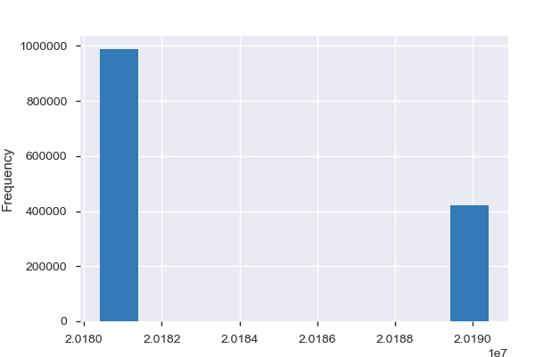

**Common Values**

| Value | Count | Frequency (%) |  |
| --- | --- | --- | --- |
| 20190213.0 | 9200 | 0.6% |  |
| 20190119.0 | 9079 | 0.6% |  |
| 20181015.0 | 8663 | 0.6% |  |
| 20190117.0 | 8577 | 0.6% |  |
| 20190112.0 | 8197 | 0.6% |  |
| 20181213.0 | 8182 | 0.6% |  |
| 20190108.0 | 8109 | 0.6% |  |
| 20190124.0 | 8023 | 0.6% |  |
| 20181224.0 | 7898 | 0.5% |  |
| 20190215.0 | 7763 | 0.5% |  |
| Other values (370) | 1325319 | 91.2% |  |
| (Missing) | 43660 | 3.0% |  |

**Extreme Values**

Minimum 5 values

| Value | Count | Frequency (%) |  |
| --- | --- | --- | --- |
| 20180402.0 | 2672 | 0.2% |  |
| 20180403.0 | 2538 | 0.2% |  |
| 20180404.0 | 2456 | 0.2% |  |
| 20180405.0 | 2626 | 0.2% |  |
| 20180406.0 | 2594 | 0.2% |  |

Maximum 5 values

| Value | Count | Frequency (%) |  |
| --- | --- | --- | --- |
| 20190412.0 | 148 | 0.0% |  |
| 20190413.0 | 269 | 0.0% |  |
| 20190414.0 | 457 | 0.0% |  |
| 20190415.0 | 203 | 0.0% |  |
| 20190416.0 | 73 | 0.0% |  |

V_SHIPPING_FCOK  
Constant

*This variable is constant and should be ignored for analysis*

| Constant value |  |
| --- | --- |

V_SPEC  
Categorical

| Distinct count | 12 |
| --- | --- |
| Unique (%) | 0.0% |
| Missing (%) | 43.6% |
| Missing (n) | 633059 |

| 000 | 701825 |
| --- | --- |
| T84 | 45010 |
| T80 | 42929 |
| Other values (8) | 29847 |
| (Missing) | 633059 |

Toggle details

| Value | Count | Frequency (%) |  |
| --- | --- | --- | --- |
| 000 | 701825 | 48.3% |  |
| T84 | 45010 | 3.1% |  |
| T80 | 42929 | 3.0% |  |
| T87 | 19555 | 1.3% |  |
| J00 | 3154 | 0.2% |  |
| T12 | 2812 | 0.2% |  |
| T01 | 1994 | 0.1% |  |
| T63 | 1099 | 0.1% |  |
| J84 | 1020 | 0.1% |  |
| T19 | 197 | 0.0% |  |
| (Missing) | 633059 | 43.6% |  |

V_SRC_DIV  
Constant

*This variable is constant and should be ignored for analysis*

| Constant value | 1 |
| --- | --- |

V_VIN  
Categorical, Unique

| First 3 values |
| --- |
| MK53S-839799 |
| JSAMFJ11S00200198 |
| TSMJYBA2S00657162 |

| Last 3 values |
| --- |
| JSAGJB74V00100509 |
| TSMLYD21S00485466 |
| FF21S-142044 |

Toggle details

| Value | Count | Frequency (%) |  |
| --- | --- | --- | --- |
| 00252F-817862 | 1 | 0.0% |  |
| 00252F-817863 | 1 | 0.0% |  |
| 00252F-817864 | 1 | 0.0% |  |
| 00252F-817865 | 1 | 0.0% |  |
| 00252F-817866 | 1 | 0.0% |  |

| Value | Count | Frequency (%) |  |
| --- | --- | --- | --- |
| ZD83S-105317 | 1 | 0.0% |  |
| ZD83S-105318 | 1 | 0.0% |  |
| ZD83S-105319 | 1 | 0.0% |  |
| ZD83S-105320 | 1 | 0.0% |  |
| ZD83S-105321 | 1 | 0.0% |  |

# Correlations

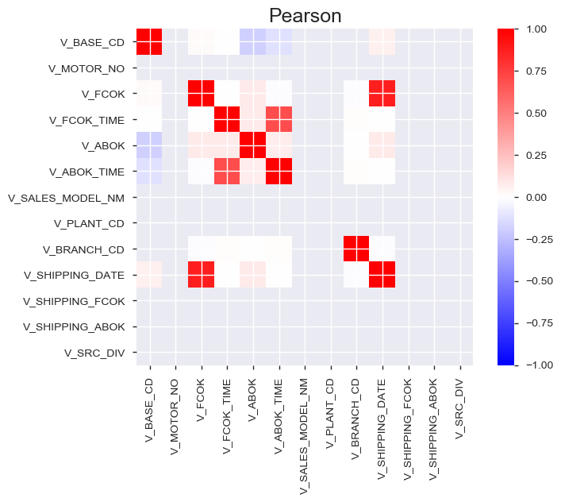

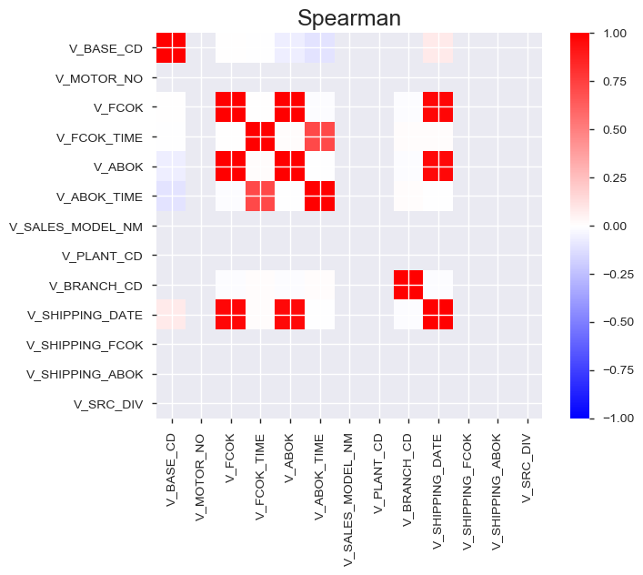

# Sample

|  | V_BASE_CD | V_PROD_DIV | V_VIN | V_ENGINE_NO | V_MOTOR_NO | V_MISSON_NO | V_KEY_NO | V_FCOK | V_FCOK_TIME | V_ABOK | V_ABOK_TIME | V_PROD_MODEL_CD | V_SALES_MODEL_CD | V_SALES_MODEL_NM | V_SPEC | V_COLOR | V_PLANT_CD | V_DIST_CD | V_BRANCH_CD | V_SHIPPING_DATE | V_SHIPPING_FCOK | V_SHIPPING_ABOK | V_INVOICE_NO | V_SALES_NO | V_CASE_NO | V_SRC_DIV | V_CRT_TIME_STAMP |
| --- | --- | --- | --- | --- | --- | --- | --- | --- | --- | --- | --- | --- | --- | --- | --- | --- | --- | --- | --- | --- | --- | --- | --- | --- | --- | --- | --- |
| 0 | 100100 | B | MK53S-861193 | R06A-B670795 | NaN | NaN | L0590 | 20190315 | 125424.0 | 20190315.0 | 112157.0 | NaN | MK53S-ZTZP-JK | NaN | 000 | ZVR | NaN | 403110 | 403080.0 | 20190313.0 | NaN | NaN | NaN | NaN | NaN | 1 | 19-04-19 15:32:01.583547000 |
| 1 | 100100 | B | MK53S-861195 | R06A-B671063 | NaN | NaN | L4800 | 20190315 | 172154.0 | 20190315.0 | 162715.0 | NaN | MK53S-ZTZB-J | NaN | 000 | DYA | NaN | 403110 | 403080.0 | 20190313.0 | NaN | NaN | NaN | NaN | NaN | 1 | 19-04-19 15:32:01.587623000 |
| 2 | 100100 | B | MK53S-861196 | R06A-B670870 | NaN | NaN | L0124 | 20190315 | 142233.0 | 20190315.0 | 132702.0 | NaN | MK53S-ZTXB-JK | NaN | 000 | ZVR | NaN | 502240 | 506070.0 | 20190313.0 | NaN | NaN | NaN | NaN | NaN | 1 | 19-04-19 15:32:01.599814000 |
| 3 | 100100 | B | MK53S-861197 | R06A-B670799 | NaN | NaN | L0635 | 20190315 | 125636.0 | 20190315.0 | 112613.0 | NaN | MK53S-ZTZP-JK | NaN | 000 | ZVC | NaN | 308010 | 308020.0 | 20190313.0 | NaN | NaN | NaN | NaN | NaN | 1 | 19-04-19 15:32:01.603856000 |
| 4 | 100100 | B | MK53S-861198 | R06A-B670875 | NaN | NaN | L0134 | 20190315 | 143021.0 | 20190315.0 | 134140.0 | NaN | MK53S-ZTZB-JK | NaN | 000 | ZVR | NaN | 500020 | 500060.0 | 20190313.0 | NaN | NaN | NaN | NaN | NaN | 1 | 19-04-19 15:32:01.606902000 |